# Linear Models Part.1

Aug, 14, 2019

## Concept of Linear models

For the given data \((y_1,x_1),\cdots,(y_n,x_n)\),

We consider the models like :

\[y_i=\beta_0+\beta_1x_i+\epsilon_i\] where \(\epsilon_i\overset{iid}{\sim}N(0,\sigma^2)\), or

\[y_{ij}=\mu+\tau_j+\epsilon_{ij}\] for \((y_{11},x_{11})\cdots,(y_{nk},x_{nk})\) where \(\epsilon_{ij}\overset{iid}{\sim}N(0,\sigma^2)\).

## Design for Linear Regression

\[{\displaystyle {\begin{bmatrix}y_{1}\\y_{2}\\y_{3}\\y_{4}\\y_{5}\\y_{6}\\y_{7}\end{bmatrix}}={\begin{bmatrix}1&x_{1}\\1&x_{2}\\1&x_{3}\\1&x_{4}\\1&x_{5}\\1&x_{6}\\1&x_{7}\end{bmatrix}}{\begin{bmatrix}\beta _{0}\\\beta _{1}\end{bmatrix}}+{\begin{bmatrix}\varepsilon _{1}\\\varepsilon _{2}\\\varepsilon _{3}\\\varepsilon _{4}\\\varepsilon _{5}\\\varepsilon _{6}\\\varepsilon _{7}\end{bmatrix}}}=\mathbf{X}\beta+\varepsilon\]

### Design for ANOVA

\[{\displaystyle \text{vec}(\mathbf{y})={\begin{bmatrix}y_{11}\\y_{21}\\y_{31}\\y_{12}\\y_{22}\\y_{13}\\y_{23}\end{bmatrix}}={\begin{bmatrix}1&0&0\\1&0&0\\1&0&0\\1&1&0\\1&1&0\\1&0&1\\1&0&1\end{bmatrix}}{\begin{bmatrix}\mu \\\tau _{2}\\\tau _{3}\end{bmatrix}}+{\begin{bmatrix}\varepsilon _{11}\\\varepsilon _{21}\\\varepsilon _{31}\\\varepsilon _{12}\\\varepsilon _{22}\\\varepsilon _{13}\\\varepsilon _{23}\end{bmatrix}=\mathbf{X}\tau+\text{vec}(\varepsilon)}}\]

## ANOVA

## Terminology

- balanced design
- within / between-groups
- main / interaction effect
- factors (Time, Location, Age, …)
- nuisance variable \(\rightarrow\) covariate \(\rightarrow\) ANCOVA
- MANOVA, MANCOVA

## Analysis of Variances

`lm(), aov()` \(\rightarrow\) `aov(formulae, data=dataframe)`

1. One-way ANOVA : `y ~ A`
2. One-way ANCOVA : `y ~ x + A`
3. Two-way ANOVA : `y ~ A * B` (Caution : order does matter)
4. Two-way ANCOVA : `y ~ x1 + x2 + A * B`
5. Randomized block : `y ~ B + A` (B = Block factor)

### Caution

For a given formulae `y ~ A + B + A:B`, `R` evaluates

1. effect of `A`
2. effect of `B` under control of `A`
3. interaction of `A,B` under control of `A,B`

```r
attach(cholesterol)
cholesterol %>% group_by(trt) %>% summarise(mean(response), sd(response), n = n())
```

```
~ # A tibble: 5 x 4
~   trt    `mean(response)` `sd(response)`     n
~   <fct>             <dbl>          <dbl> <int>
~ 1 1time              5.78           2.88    10
~ 2 2times             9.22           3.48    10
~ 3 4times            12.4            2.92    10
~ 4 drugD             15.4            3.45    10
~ 5 drugE             20.9            3.35    10
```

```r
fit <- aov(response ~ trt)
summary(fit)
```

```
~             Df Sum Sq Mean Sq F value   Pr(>F)
~ trt          4 1351.4   337.8   32.43 9.82e-13 ***
~ Residuals   45  468.8    10.4
~ ---
~ Signif. codes:  0 '***' 0.001 '**' 0.01 '*' 0.05 '.' 0.1 ' ' 1
```

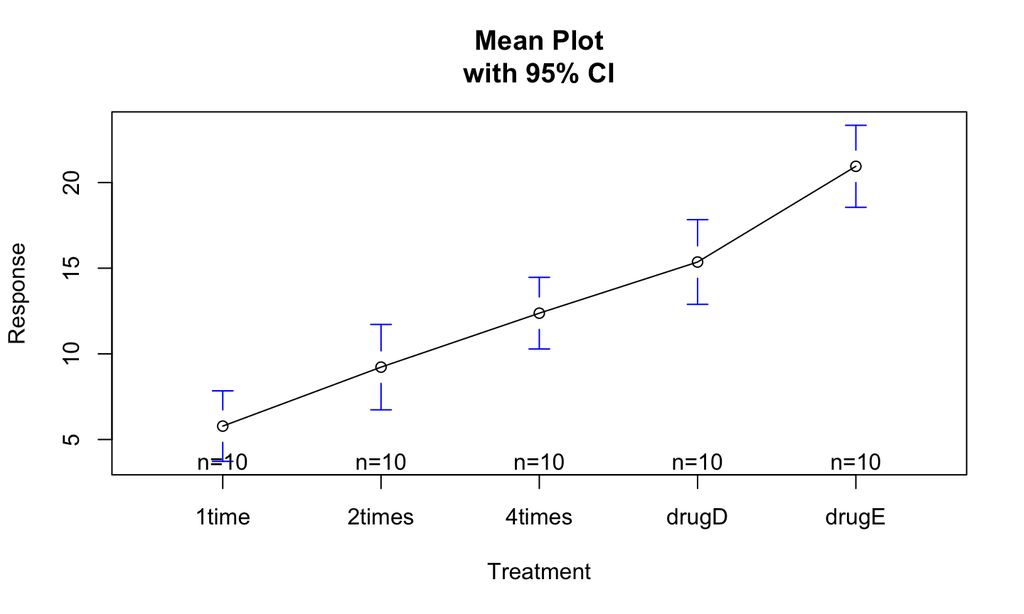

```r
library(gplots)
plotmeans(response ~ trt, xlab="Treatment", ylab="Response",
          main="Mean Plot\nwith 95% CI")
```

```r
detach(cholesterol)
```

### Tukey HSD pairwise group comparisons (so called post hoc analysis)

```r
TukeyHSD(fit)
```

```
~   Tukey multiple comparisons of means
~     95% family-wise confidence level
~
~ Fit: aov(formula = response ~ trt)
~
~ $trt
~                   diff        lwr       upr     p adj
~ 2times-1time   3.44300 -0.6582817  7.544282 0.1380949
~ 4times-1time   6.59281  2.4915283 10.694092 0.0003542
~ drugD-1time    9.57920  5.4779183 13.680482 0.0000003
~ drugE-1time   15.16555 11.0642683 19.266832 0.0000000
~ 4times-2times  3.14981 -0.9514717  7.251092 0.2050382
~ drugD-2times   6.13620  2.0349183 10.237482 0.0009611
~ drugE-2times  11.72255  7.6212683 15.823832 0.0000000
~ drugD-4times   2.98639 -1.1148917  7.087672 0.2512446
~ drugE-4times   8.57274  4.4714583 12.674022 0.0000037
~ drugE-drugD    5.58635  1.4850683  9.687632 0.0030633
```

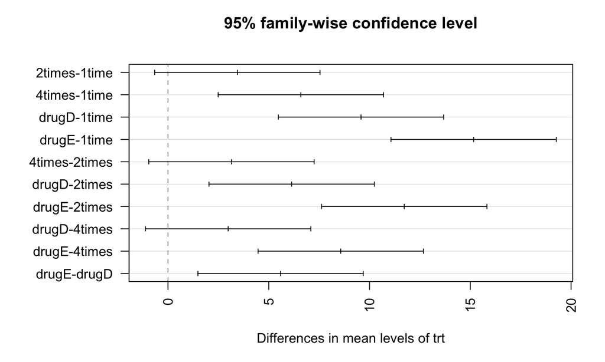

```r
par(las=2)
par(mar=c(5,8,4,2))
plot(TukeyHSD(fit))
```

```r
par(opar)
```

### Multiple comparisons

Pairs of same labels indicate no statistical difference  
remember : also applicable on generalized linear model.

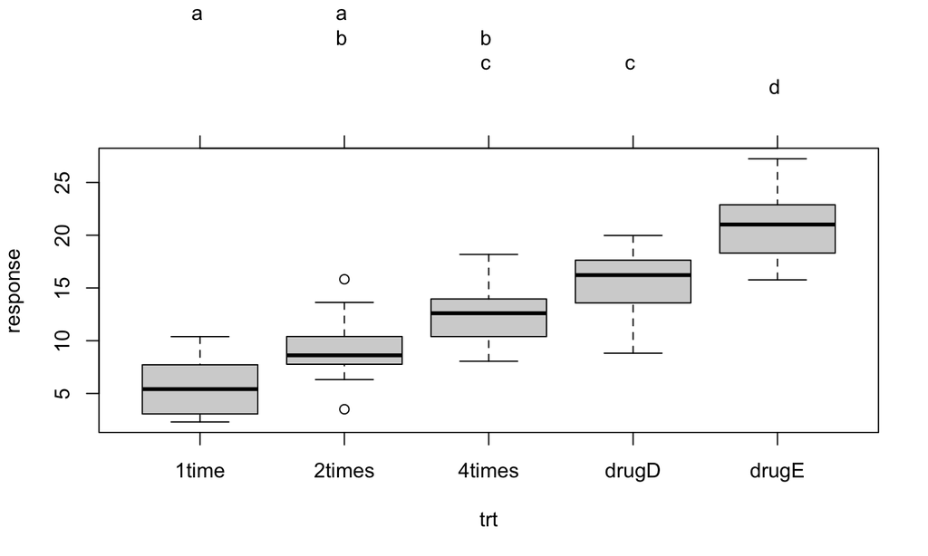

```r
library(multcomp)
par(mar=c(5,4,6,2))
tuk <- glht(fit, linfct=mcp(trt="Tukey"))
plot(cld(tuk, level=.05),col="lightgrey")
```

```r
par(opar)
```

### Assessing normality

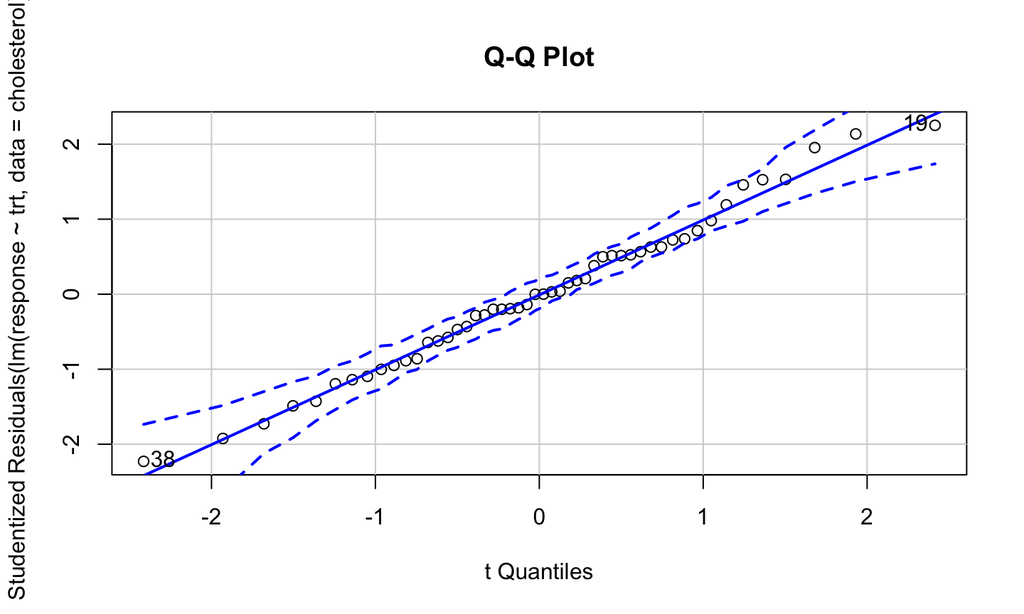

```r
library(car)
qqPlot(lm(response ~ trt, data=cholesterol),
       simulate=TRUE, main="Q-Q Plot", labels=FALSE)
```

```
~ [1] 19 38
```

### Assessing homogeneity of variances

```r
bartlett.test(response ~ trt, data=cholesterol)
```

```
~
~   Bartlett test of homogeneity of variances
~
~ data:  response by trt
~ Bartlett's K-squared = 0.57975, df = 4, p-value = 0.9653
```

```r
outlierTest(fit)
```

```
~ No Studentized residuals with Bonferroni p < 0.05
~ Largest |rstudent|:
~    rstudent unadjusted p-value Bonferroni p
~ 19 2.251149           0.029422           NA
```

## One-way ANCOVA (Analysis of Covariances)

- unbalenced design (order of effects does matter)

```r
data(litter, package="multcomp")
attach(litter)
litter %>% group_by(dose) %>% summarise(mean(weight), n=n())
```

```
~ # A tibble: 4 x 3
~   dose  `mean(weight)`     n
~   <fct>          <dbl> <int>
~ 1 0               32.3    20
~ 2 5               29.3    19
~ 3 50              29.9    18
~ 4 500             29.6    17
```

```r
fit <- aov(weight ~ gesttime + dose)
summary(fit)
```

```
~             Df Sum Sq Mean Sq F value  Pr(>F)
~ gesttime     1  134.3  134.30   8.049 0.00597 **
~ dose         3  137.1   45.71   2.739 0.04988 *
~ Residuals   69 1151.3   16.69
~ ---
~ Signif. codes:  0 '***' 0.001 '**' 0.01 '*' 0.05 '.' 0.1 ' ' 1
```

### Obtaining effect of factor : elimination of covariate effect

```r
library(effects)
effect("dose", fit)
```

```
~
~  dose effect
~ dose
~        0        5       50      500
~ 32.35367 28.87672 30.56614 29.33460
```

### Multiple comparisons using user supplied contrasts

- use contrast

```r
contrast <- rbind("no drug - drug" = c(3, -1, -1, -1),
                   "50 - 500" = c(0, 0, 1, -1))
mcp(dose = contrast)
```

```
~ $dose
~                [,1] [,2] [,3] [,4]
~ no drug - drug    3   -1   -1   -1
~ 50 - 500          0    0    1   -1
~
~ attr(,"interaction_average")
~ [1] FALSE
~ attr(,"covariate_average")
~ [1] FALSE
~ attr(,"class")
~ [1] "mcp"
```

```r
summary(glht(fit, linfct = mcp(dose=contrast)))
```

```
~
~    Simultaneous Tests for General Linear Hypotheses
~
~ Multiple Comparisons of Means: User-defined Contrasts
~
~
~ Fit: aov(formula = weight ~ gesttime + dose)
~
~ Linear Hypotheses:
~                     Estimate Std. Error t value Pr(>|t|)
~ no drug - drug == 0    8.284      3.209   2.581   0.0237 *
~ 50 - 500 == 0          1.232      1.419   0.868   0.6245
~ ---
~ Signif. codes:  0 '***' 0.001 '**' 0.01 '*' 0.05 '.' 0.1 ' ' 1
~ (Adjusted p values reported -- single-step method)
```

### Testing for homegeneity of regression slopes

In ANCOVA, we make an additional assumption such that the slopes of regression lines of all factors are the same.

```r
fit2 <- aov(weight ~ gesttime*dose, data=litter)
summary(fit2) # interaction is not significant, so okay to proceed
```

```
~               Df Sum Sq Mean Sq F value  Pr(>F)
~ gesttime       1  134.3  134.30   8.289 0.00537 **
~ dose           3  137.1   45.71   2.821 0.04556 *
~ gesttime:dose  3   81.9   27.29   1.684 0.17889
~ Residuals     66 1069.4   16.20
~ ---
~ Signif. codes:  0 '***' 0.001 '**' 0.01 '*' 0.05 '.' 0.1 ' ' 1
```

### Visualizing a one-way ANCOVA

```r
HH::ancova(weight ~ gesttime*dose, data=litter)
```

```
~ Analysis of Variance Table
~
~ Response: weight
~               Df  Sum Sq Mean Sq F value   Pr(>F)
~ gesttime       1  134.30 134.304  8.2888 0.005372 **
~ dose           3  137.12  45.708  2.8209 0.045562 *
~ gesttime:dose  3   81.87  27.289  1.6842 0.178889
~ Residuals     66 1069.40  16.203
~ ---
~ Signif. codes:  0 '***' 0.001 '**' 0.01 '*' 0.05 '.' 0.1 ' ' 1
```

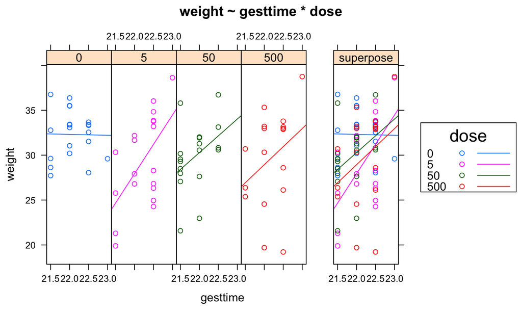

## Two way ANOVA

```r
attach(ToothGrowth)
```

```
~ The following object is masked from litter:
~
~     dose
```

```r
table(supp,dose)
```

```
~     dose
~ supp 0.5  1  2
~   OJ  10 10 10
~   VC  10 10 10
```

```r
ToothGrowth %>% group_by(supp,dose) %>% summarise(mean(len), sd(len))
```

```
~ # A tibble: 6 x 4
~ # Groups:   supp [2]
~   supp   dose `mean(len)` `sd(len)`
~   <fct> <dbl>       <dbl>     <dbl>
~ 1 OJ      0.5       13.2       4.46
~ 2 OJ      1         22.7       3.91
~ 3 OJ      2         26.1       2.66
~ 4 VC      0.5        7.98      2.75
~ 5 VC      1         16.8       2.52
~ 6 VC      2         26.1       4.80
```

```r
dose <- factor(dose)
fit <- aov(len ~ supp*dose)
summary(fit)
```

```
~             Df Sum Sq Mean Sq F value   Pr(>F)
~ supp         1  205.4   205.4  15.572 0.000231 ***
~ dose         2 2426.4  1213.2  92.000  < 2e-16 ***
~ supp:dose    2  108.3    54.2   4.107 0.021860 *
~ Residuals   54  712.1    13.2
~ ---
~ Signif. codes:  0 '***' 0.001 '**' 0.01 '*' 0.05 '.' 0.1 ' ' 1
```

### plotting interactions

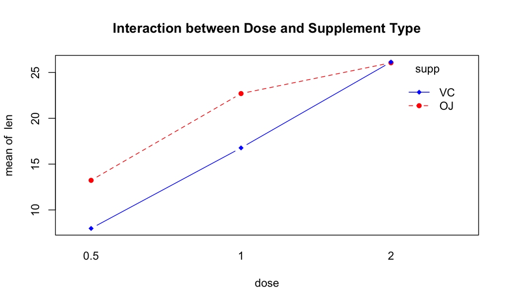

```r
interaction.plot(dose, supp, len, type="b",
                 col=c("red","blue"), pch=c(16, 18),
                 main = "Interaction between Dose and Supplement Type")
```

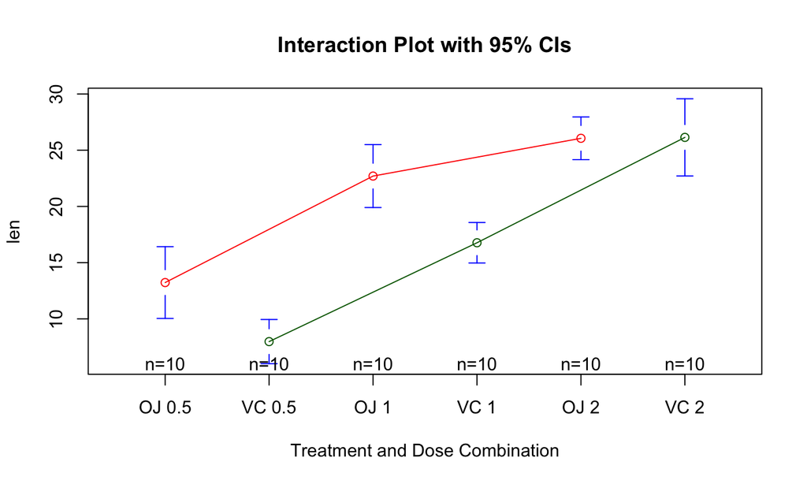

```r
plotmeans(len ~ interaction(supp, dose, sep=" "),
          connect=list(c(1, 3, 5),c(2, 4, 6)),
          col=c("red","darkgreen"),
          main = "Interaction Plot with 95% CIs",
          xlab="Treatment and Dose Combination")
```

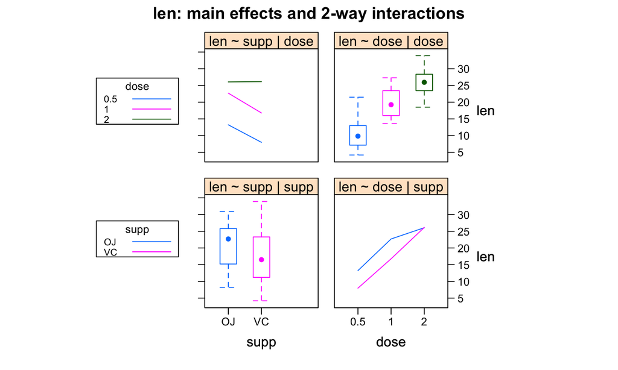

```r
interaction2wt(len~supp*dose)
```

### Multiple comparison

```r
TukeyHSD(fit)
```

```
~   Tukey multiple comparisons of means
~     95% family-wise confidence level
~
~ Fit: aov(formula = len ~ supp * dose)
~
~ $supp
~       diff       lwr       upr     p adj
~ VC-OJ -3.7 -5.579828 -1.820172 0.0002312
~
~ $dose
~         diff       lwr       upr   p adj
~ 1-0.5  9.130  6.362488 11.897512 0.0e+00
~ 2-0.5 15.495 12.727488 18.262512 0.0e+00
~ 2-1    6.365  3.597488  9.132512 2.7e-06
~
~ $`supp:dose`
~                diff        lwr        upr     p adj
~ VC:0.5-OJ:0.5 -5.25 -10.048124 -0.4518762 0.0242521
~ OJ:1-OJ:0.5    9.47   4.671876 14.2681238 0.0000046
~ VC:1-OJ:0.5    3.54  -1.258124  8.3381238 0.2640208
~ OJ:2-OJ:0.5   12.83   8.031876 17.6281238 0.0000000
~ VC:2-OJ:0.5   12.91   8.111876 17.7081238 0.0000000
~ OJ:1-VC:0.5   14.72   9.921876 19.5181238 0.0000000
~ VC:1-VC:0.5    8.79   3.991876 13.5881238 0.0000210
~ OJ:2-VC:0.5   18.08  13.281876 22.8781238 0.0000000
~ VC:2-VC:0.5   18.16  13.361876 22.9581238 0.0000000
~ VC:1-OJ:1     -5.93 -10.728124 -1.1318762 0.0073930
~ OJ:2-OJ:1      3.36  -1.438124  8.1581238 0.3187361
~ VC:2-OJ:1      3.44  -1.358124  8.2381238 0.2936430
~ OJ:2-VC:1      9.29   4.491876 14.0881238 0.0000069
~ VC:2-VC:1      9.37   4.571876 14.1681238 0.0000058
~ VC:2-OJ:2      0.08  -4.718124  4.8781238 1.0000000
```

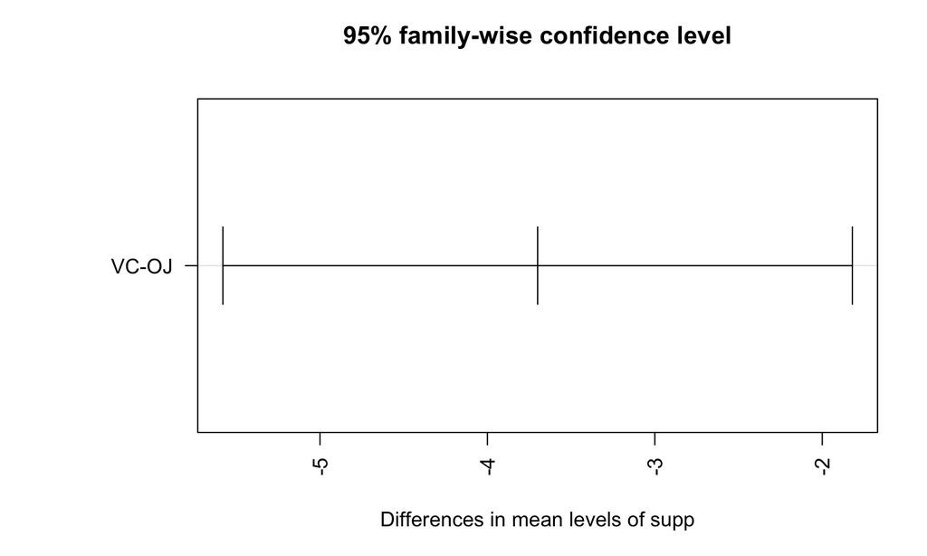

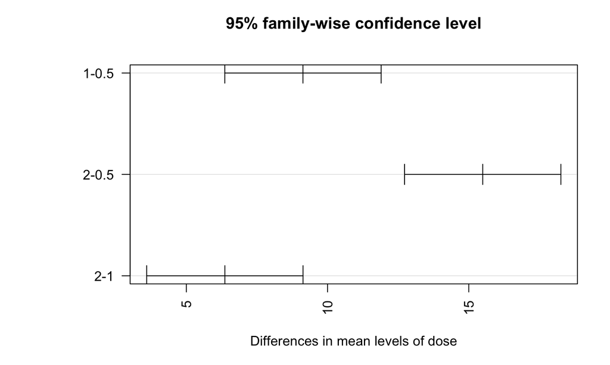

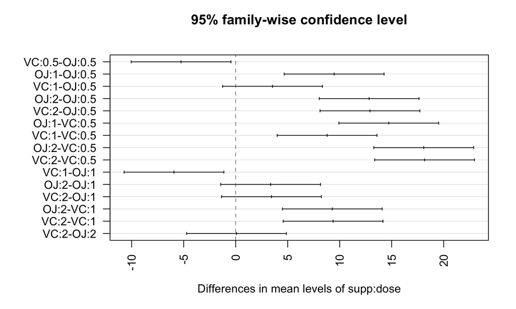

```r
par(las=2)
par(mar=c(5,8,4,2))
plot(TukeyHSD(fit))
```

```r
par(opar)
```

## Repeated measures ANOVA with one between and within groups factor

- `CO2` data : *The Statistical Analysis of Ecophysiological Response Curves Obtained from Experiments Involving Repeated Measures, Ecological Society of America, Potvin et al., 1990*

The CO2 dependence of photosynthesis in the C4 grass *Echinochloa crus—galli* following chilling area

[figure not shown]

- `Plant` : an ordered factor with levels Qn1 < Qn2 < Qn3 < … < Mc1 giving a unique identifier for each plant.
- `Type` *(B factor)* : a factor with levels Quebec Mississippi giving the origin of the plant
- `Treatment` : a factor with levels nonchilled/chilled
- `conc` *(W factor)* : a numeric vector of ambient carbon dioxide concentrations (mL/L).
- `uptake` : a numeric vector of carbon dioxide uptake rates (umol/m^2 sec).

```r
CO2$conc <- factor(CO2$conc)
w1b1 <- subset(CO2, Treatment=='chilled') # Only chilled ones
fit <- aov(uptake ~ (conc*Type) + Error(Plant/(conc)), w1b1)
summary(fit)
```

```
~
~ Error: Plant
~           Df Sum Sq Mean Sq F value  Pr(>F)
~ Type       1 2667.2  2667.2   60.41 0.00148 **
~ Residuals  4  176.6    44.1
~ ---
~ Signif. codes:  0 '***' 0.001 '**' 0.01 '*' 0.05 '.' 0.1 ' ' 1
~
~ Error: Plant:conc
~           Df Sum Sq Mean Sq F value   Pr(>F)
~ conc       6 1472.4  245.40   52.52 1.26e-12 ***
~ conc:Type  6  428.8   71.47   15.30 3.75e-07 ***
~ Residuals 24  112.1    4.67
~ ---
~ Signif. codes:  0 '***' 0.001 '**' 0.01 '*' 0.05 '.' 0.1 ' ' 1
```

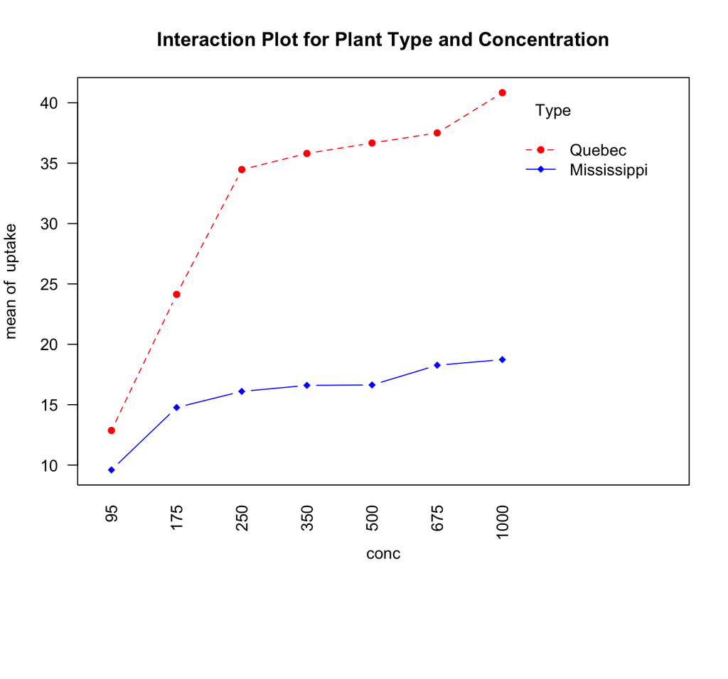

```r
par(las=2)
par(mar=c(10,4,4,2))
with(w1b1,
     interaction.plot(conc,Type,uptake,
                      type="b", col=c("red","blue"), pch=c(16,18),
                      main="Interaction Plot for Plant Type and Concentration"))
```

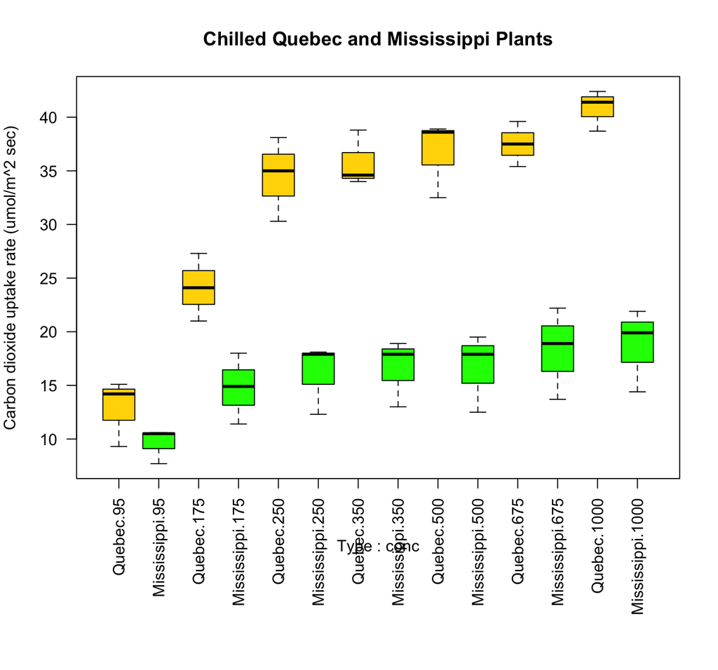

```r
boxplot(uptake ~ Type*conc, data=w1b1, col=(c("gold","green")),
        main="Chilled Quebec and Mississippi Plants",
        ylab="Carbon dioxide uptake rate (umol/m^2 sec)")
```

```r
par(opar)
```

CO2 uptakes of plants in Quebec is greater than is in Mississippi.  
CO2 concentration also affects the effect of B factor ; Type.

## One-way MANOVA

- `shelf` *(B factor)* : display shelf (1, 2, or 3, counting from the floor).

```r
library(MASS)
attach(UScereal)
shelf <- factor(shelf)
y <- cbind(calories, fat, sugars)
UScereal %>% group_by(shelf) %>% summarise_at(., vars(calories, fat, sugars), mean)
```

```
~ # A tibble: 3 x 4
~   shelf calories   fat sugars
~   <int>    <dbl> <dbl>  <dbl>
~ 1     1     119. 0.662   6.30
~ 2     2     130. 1.34   12.5
~ 3     3     180. 1.94   10.9
```

```r
cov(y)
```

```
~            calories       fat     sugars
~ calories 3895.24210 60.674383 180.380317
~ fat        60.67438  2.713399   3.995474
~ sugars    180.38032  3.995474  34.050018
```

```r
fit <- manova(y ~ shelf)
summary(fit)
```

```
~           Df Pillai approx F num Df den Df    Pr(>F)
~ shelf      2 0.4021   5.1167      6    122 0.0001015 ***
~ Residuals 62
~ ---
~ Signif. codes:  0 '***' 0.001 '**' 0.01 '*' 0.05 '.' 0.1 ' ' 1
```

```r
summary.aov(fit)
```

```
~  Response calories :
~             Df Sum Sq Mean Sq F value    Pr(>F)
~ shelf        2  50435 25217.6  7.8623 0.0009054 ***
~ Residuals   62 198860  3207.4
~ ---
~ Signif. codes:  0 '***' 0.001 '**' 0.01 '*' 0.05 '.' 0.1 ' ' 1
~
~  Response fat :
~             Df Sum Sq Mean Sq F value  Pr(>F)
~ shelf        2  18.44  9.2199  3.6828 0.03081 *
~ Residuals   62 155.22  2.5035
~ ---
~ Signif. codes:  0 '***' 0.001 '**' 0.01 '*' 0.05 '.' 0.1 ' ' 1
~
~  Response sugars :
~             Df  Sum Sq Mean Sq F value   Pr(>F)
~ shelf        2  381.33 190.667  6.5752 0.002572 **
~ Residuals   62 1797.87  28.998
~ ---
~ Signif. codes:  0 '***' 0.001 '**' 0.01 '*' 0.05 '.' 0.1 ' ' 1
```

### Assessing multivariate normality

- Mahalanobis distance statistics : \((\mathbf{x}-\mu)'S^{-1}(\mathbf{x}-\mu)\sim \chi^2(p)\)

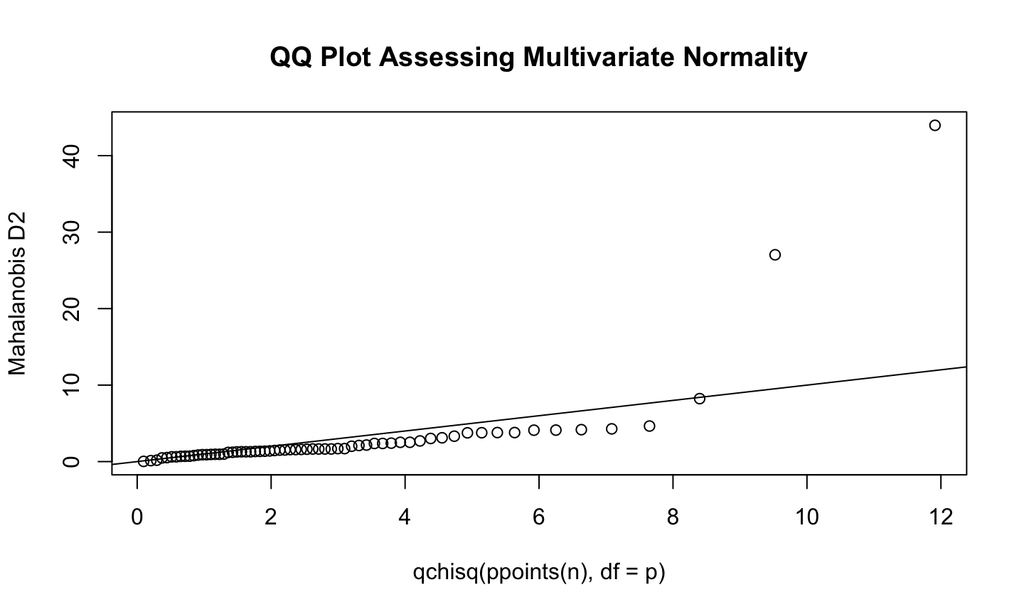

```r
center <- colMeans(y)
n <- nrow(y)
p <- ncol(y)
cov <- cov(y)
d <- mahalanobis(y,center,cov)
coord <- qqplot(qchisq(ppoints(n),df=p),
                d, main="QQ Plot Assessing Multivariate Normality",
                ylab="Mahalanobis D2")
abline(a=0, b=1)
identify(coord$x, coord$y, labels=row.names(UScereal))
```

```
~ integer(0)
```

Normality violated due to the outliers.

## Multivariate outliers

```r
library(mvoutlier)
outliers <- aq.plot(y)
```

```
~ Projection to the first and second robust principal components.
~ Proportion of total variation (explained variance): 0.9805626
```

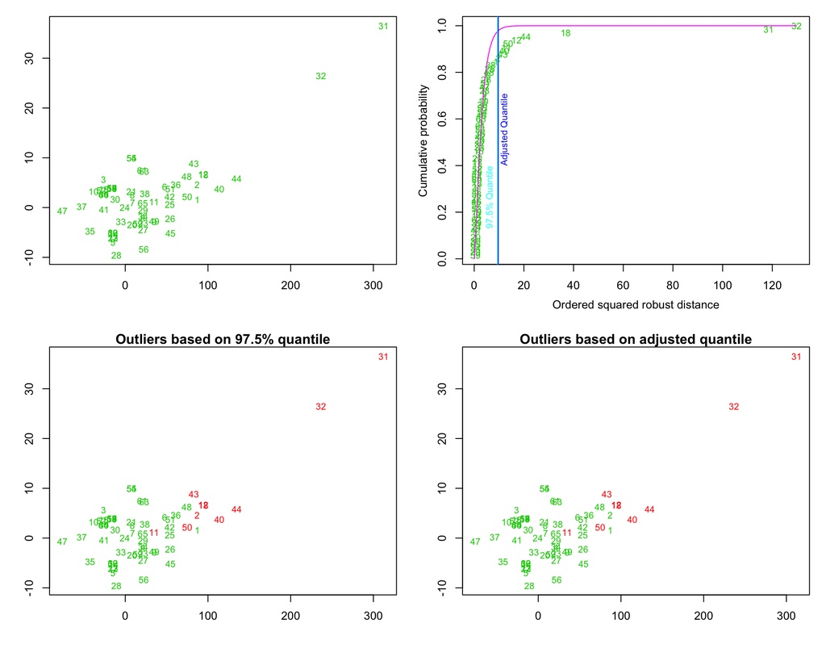

```r
outliers
```

```
~ $outliers
~  [1] FALSE FALSE FALSE FALSE FALSE FALSE FALSE FALSE FALSE FALSE  TRUE
~ [12]  TRUE FALSE FALSE FALSE FALSE FALSE  TRUE FALSE FALSE FALSE FALSE
~ [23] FALSE FALSE FALSE FALSE FALSE FALSE FALSE FALSE  TRUE  TRUE FALSE
~ [34] FALSE FALSE FALSE FALSE FALSE FALSE  TRUE FALSE FALSE  TRUE  TRUE
~ [45] FALSE FALSE FALSE FALSE FALSE  TRUE FALSE FALSE FALSE FALSE FALSE
~ [56] FALSE FALSE FALSE FALSE FALSE FALSE FALSE FALSE FALSE FALSE
```

## Robust one-way MANOVA

```r
library(rrcov)
Wilks.test(y,shelf, method="mcd")  # this can take a while
```

```
~
~   Robust One-way MANOVA (Bartlett Chi2)
~
~ data:  x
~ Wilks' Lambda = 0.51073, Chi2-Value = 22.8142, DF = 4.6643,
~ p-value = 0.0002679
~ sample estimates:
~   calories       fat    sugars
~ 1 119.8210 0.7010828  5.663143
~ 2 128.0407 1.1849576 12.537533
~ 3 160.8604 1.6524559 10.352646
```

## A regression approach to the ANOVA problem

```r
fit.lm <- lm(response ~ trt, data=cholesterol)
summary(fit.lm)
```

```
~
~ Call:
~ lm(formula = response ~ trt, data = cholesterol)
~
~ Residuals:
~     Min      1Q  Median      3Q     Max
~ -6.5418 -1.9672 -0.0016  1.8901  6.6008
~
~ Coefficients:
~             Estimate Std. Error t value Pr(>|t|)
~ (Intercept)    5.782      1.021   5.665 9.78e-07 ***
~ trt2times      3.443      1.443   2.385   0.0213 *
~ trt4times      6.593      1.443   4.568 3.82e-05 ***
~ trtdrugD       9.579      1.443   6.637 3.53e-08 ***
~ trtdrugE      15.166      1.443  10.507 1.08e-13 ***
~ ---
~ Signif. codes:  0 '***' 0.001 '**' 0.01 '*' 0.05 '.' 0.1 ' ' 1
~
~ Residual standard error: 3.227 on 45 degrees of freedom
~ Multiple R-squared:  0.7425,  Adjusted R-squared:  0.7196
~ F-statistic: 32.43 on 4 and 45 DF,  p-value: 9.819e-13
```

```r
contrasts(cholesterol$trt)
```

```
~        2times 4times drugD drugE
~ 1time       0      0     0     0
~ 2times      1      0     0     0
~ 4times      0      1     0     0
~ drugD       0      0     1     0
~ drugE       0      0     0     1
```